# Develop a pass/fail filter for Telog Level Validation results

Hao Zhang

Feburary 16, 2017

### Objectives

Systemwide model validation generates a set of RCalibration results for each monitor, and it’s not feasible to investigate all the plots and stats. it is necessary to find a systematic approach to characterize the systemwide validation results as either pass or fail, and possibly rank monitors for further investigations.

### Introduction

For systemwide validation, the Telog level data is compared with the model output. The `rebuild2016_20170124_systemwide` model is used to generate the modeled levels. A total of 425 measurements, including `TRUNK_LEVEL`, `SWO_LEVEL`, `INTERCEPTER_LEVEL`, and `DWO_LEVEL`, were validated for the year of **2016**.

The `RCalibration_Level_2.1.1_batch.R` script is used to generate validation results.

The output is saved at: `D:/Data/LevelValidation2016/Validation/validation_RCal_runs_20170124`.

There is also a copy at `M:/Model_Calibration_Validation/TelogLevelMon/20170124_Validation`, except for a few files that the file path is too long.

For each measurement, the validation inspects for 3 metrics:

- **Volume**: not actual volume, but integral levels
- **Peak**: maximum level, most likely during a storm
- **time-to-peak**: which is always good

Within each metric, inter-event and intra-event **stats** and **plots** are generated:

- **Scatter plot**: meas vs mod, one point per event, characterized by NRMSE, Rsq
- **CDF**: cumulative density function, meas vs mod, one point per event, no stats
- **Difference**: only for ttp, (mod - meas) vs. event, one point per event, no stats
- **Cumuative Residual**: cumu.residual vs. event, one point per event, checked against 80% Probability Ellipse
- **DMR**: Double mass Regression, meas vs mod, one point per event, characterized by NRMSE and slope and/or intercept. (fit to both y=mx and y=mx+b model)

  (DMR: an analysis for investigating the behaviour of records made of hydrological or meteorological data at a number of locations, e.g., to determine whether there is a need for corrections to the data, or checking consistency of a hydrological or meteorological record)
- **Time-series**: level vs time, one plot per event

The **statistics** that were calculated are:

- **NSE**: Nash-Sutcliffe efficiency, used to assess the predictive power of hydrological models, range from −∞ to 1. Essentially, the closer the model efficiency is to 1, the more accurate the model is.
  - An efficiency of 1 (E = 1) corresponds to a perfect match of modeled discharge to the observed data
  - An efficiency of 0 (E = 0) indicates that the model predictions are as accurate as the mean of the observed data
  - an efficiency less than zero (E < 0) occurs when the observed mean is a better predictor than the model or, in other words, when the residual variance (described by the numerator in the expression above), is larger than the data variance (described by the denominator)
- **NRMSE**: Normalized root-mean-square deviation (error), facilitates the comparison between datasets or models with different scales. Often expressed as a percentage, where lower values indicate less residual variance.
- **Rsq, PValue, Slope, Intercept**: coefficients and parameters for fitting the meas vs. mod scatter plot by linear regression

### Single Event Analysis

The May 06, 2016 event time-series plots for all measurements were extracted and saved in the `AllSummary_TS_plots` folder. A visual check for the goodness-of-fit were perfomed manually. The outcome, `valid_status`, is “NA” for bad data, “todo” for bad fit, or “ok” for good fit.

The results are saved in a tracking sheet at: `//pwdhqr/oows/Modeling/Model_Calibration_Validation/TelogLevelMon/Status_Summary_Telog_Level_Sites_2017-01-24.xlsx`

| site_name | site_id | meas_name | meas_id | mon_id | valid_status | valid_notes | mod_link | mod_node | type | timestep | mon_flag |
| --- | --- | --- | --- | --- | --- | --- | --- | --- | --- | --- | --- |
| C_01 | 177 | TRUNK_LEVEL | 1761 | C_01_TRUNK_LEVEL_1761 | ok | pattern matches well | TC01-102 | C01 | slot | 2.5 | 1 |
| C_01 | 177 | SWO_LEVEL | 1762 | C_01_SWO_LEVEL_1762 | todo | Update model to represent SWO level better; unrealistic outlet offset | NA | OC01-002 | slot | 2.5 | 1 |
| C_02 | 286 | SWO_LEVEL | 2007 | C_02_SWO_LEVEL_2007 | NA | Monitor out | NA | OC02-000 | slot | 2.5 | 0 |
| C_02 | 286 | TRUNK_LEVEL | 2006 | C_02_TRUNK_LEVEL_2006 | NA | Monitor out | TC02-102 | C02 | slot | 2.5 | 0 |
| C_04 | 407 | SWO_LEVEL | 4163 | C_04_SWO_LEVEL_4163 | ok | NA | NA | OC04-000 | slot | 2.5 | 1 |
| C_04 | 407 | TRUNK_LEVEL | 4162 | C_04_TRUNK_LEVEL_4162 | todo | Doesn't match well | TC04-106 | C04 | slot | 2.5 | 1 |
| C_05 | 137 | DWO_LEVEL | 6148 | C_05_DWO_LEVEL_6148 | ok | NA | C05DWO | NA | slot | 2.5 | 1 |
| C_05 | 137 | SWO_LEVEL | 1458 | C_05_SWO_LEVEL_1458 | todo | sensor seems affected by creek level | NA | OC05-000 | slot | 2.5 | 1 |
| C_05 | 137 | TRUNK_LEVEL | 1457 | C_05_TRUNK_LEVEL_1457 | ok | better than C04_TRUNK | TC05-106 | C05 | slot | 2.5 | 1 |
| C_06 | 233 | SWO_LEVEL | 2185 | C_06_SWO_LEVEL_2185 | ok | NA | NA | OC06-000 | slot | 2.5 | 1 |

[output cut: 445 more lines]

The event stats are summarized below, note that some sites don’t have stats due to bad data:

| site | EVENT | Good_Bad | Event_Start_Date | Event_End_Date | Monitor_Vol_inch.days | Model_Vol_inch.days | Model_Range_Peaklevel_Dtime | Model_Range_Peaklevel_inches | Model_Peaklevel_Dtime | Model_Peaklevel_inches | Monitor_Peaklevel_Dtime | Monitor_Peaklevel_inches | Monitor_TTP | Model_TTP | NSE | Total_Rainfall_in | Peak_Rainfall_Dtime | Peak_RainIntensity_in_hr |
| --- | --- | --- | --- | --- | --- | --- | --- | --- | --- | --- | --- | --- | --- | --- | --- | --- | --- | --- |
| C_01_TRUNK_LEVEL | 22 | good | 2016-05-06 02:00:00 | 2016-05-07 11:45:00 | 5.740457e+00 | 4.023999e+00 | 2016-05-06 09:15:00 | 9.712254e+00 | 2016-05-06 09:15:00 | 9.712254e+00 | 2016-05-06 09:45:00 | 11.8850287 | 7.75 | 7.25 | 0.494 | 1.672 | 2016-05-06 12:45:00 | 0.636 |
| C_01_SWO_LEVEL | 22 | good | 2016-05-06 02:00:00 | 2016-05-07 11:45:00 | 3.492192e+00 | 3.275558e-02 | 2016-05-06 09:15:00 | 1.933692e+00 | 2016-05-06 09:15:00 | 1.933692e+00 | 2016-05-06 09:45:00 | 12.9922218 | 7.75 | 7.25 | -0.838 | 1.672 | 2016-05-06 12:45:00 | 0.636 |
| C_04_SWO_LEVEL | 22 | good | 2016-05-06 02:00:00 | 2016-05-07 11:45:00 | 7.343451e-01 | 1.084355e-01 | 2016-05-06 09:15:00 | 4.398806e+00 | 2016-05-06 09:15:00 | 4.398806e+00 | 2016-05-06 09:00:00 | 3.3734800 | 7.00 | 7.25 | -1.365 | 1.672 | 2016-05-06 12:45:00 | 0.636 |
| C_04_TRUNK_LEVEL | 22 | good | 2016-05-06 02:00:00 | 2016-05-07 11:45:00 | 4.976545e+00 | 2.583499e+00 | 2016-05-06 09:00:00 | 6.734164e+00 | 2016-05-06 09:00:00 | 6.734164e+00 | 2016-05-06 09:00:00 | 27.2238976 | 7.00 | 7.00 | 0.186 | 1.672 | 2016-05-06 12:45:00 | 0.636 |
| C_05_DWO_LEVEL | 22 | good | 2016-05-06 02:00:00 | 2016-05-07 11:45:00 | 3.621941e+00 | 3.349996e+00 | 2016-05-06 09:15:00 | 1.200000e+01 | 2016-05-06 09:15:00 | 1.200000e+01 | 2016-05-06 09:00:00 | 10.5096873 | 7.00 | 7.25 | 0.741 | 1.672 | 2016-05-06 12:45:00 | 0.636 |
| C_05_SWO_LEVEL | 22 | good | 2016-05-06 02:00:00 | 2016-05-07 11:45:00 | 1.756526e+00 | 4.670357e-03 | 2016-05-07 11:45:00 | 1.199978e-03 | 2016-05-06 09:15:00 | 1.532516e-01 | 2016-05-07 10:30:00 | 1.5742910 | 32.50 | 33.75 | -13.503 | 1.672 | 2016-05-06 12:45:00 | 0.636 |
| C_05_TRUNK_LEVEL | 22 | good | 2016-05-06 02:00:00 | 2016-05-07 11:45:00 | 4.265506e+00 | 3.710428e+00 | 2016-05-06 09:00:00 | 8.830595e+00 | 2016-05-06 09:00:00 | 8.830595e+00 | 2016-05-06 09:00:00 | 13.2776702 | 7.00 | 7.00 | 0.633 | 1.672 | 2016-05-06 12:45:00 | 0.636 |
| C_06_SWO_LEVEL | 22 | good | 2016-05-06 02:00:00 | 2016-05-07 11:45:00 | 1.447245e+00 | 7.367200e-01 | 2016-05-06 09:15:00 | 1.208457e+01 | 2016-05-06 09:15:00 | 1.208457e+01 | 2016-05-06 08:45:00 | 7.4130056 | 6.75 | 7.25 | -0.091 | 1.672 | 2016-05-06 12:45:00 | 0.636 |
| C_06_TRUNK_LEVEL | 22 | good | 2016-05-06 02:00:00 | 2016-05-07 11:45:00 | 7.667729e+00 | 5.607713e+00 | 2016-05-06 09:00:00 | 1.946877e+01 | 2016-05-06 09:00:00 | 1.946877e+01 | 2016-05-06 09:00:00 | 16.0629536 | 7.00 | 7.00 | 0.451 | 1.672 | 2016-05-06 12:45:00 | 0.636 |
| C_07_SWO_LEVEL | 22 | good | 2016-05-06 02:00:00 | 2016-05-07 11:45:00 | 2.946390e-01 | 6.486806e-02 | 2016-05-06 09:00:00 | 3.401524e+00 | 2016-05-06 09:00:00 | 3.401524e+00 | 2016-05-06 08:45:00 | 4.5844727 | 6.75 | 7.00 | 0.373 | 1.672 | 2016-05-06 12:45:00 | 0.636 |

[output cut: 388 more lines]

### Multiple Event Analysis

The inter-events stats are summarized below:

| site | good_events_volume | bad_events_volume | NRMSE_fit_volume | NRMSE_45line_volume | Rsq_volume | PValue_slope_volume | PValue_intercept_volume | Slope_volume | Slope_error_volume | Intercept_volume | Intercept_error_volume | good_events.1_peaklevel | bad_events.1_peaklevel | NRMSE_fit.1_peaklevel | NRMSE_45line.1_peaklevel | Rsq.1_peaklevel | PValue_slope.1_peaklevel | PValue_intercept.1_peaklevel | Slope.1_peaklevel | Slope_error.1_peaklevel | Intercept.1_peaklevel | Intercept_error.1_peaklevel |
| --- | --- | --- | --- | --- | --- | --- | --- | --- | --- | --- | --- | --- | --- | --- | --- | --- | --- | --- | --- | --- | --- | --- |
| C_01_TRUNK_LEVEL | 52 | 8 | 0.050191771 | 0.18206960 | 9.427245e-01 | 4.970422e-26 | 1.130635e-06 | 5.826859e-01 | 2.031149e-02 | 0.3001021748 | 0.054184734 | 52 | 8 | 0.082095654 | 0.16343258 | 8.834696e-01 | 8.292238e-09 | 6.713650e-01 | 7.380504e-01 | 3.790747e-02 | -0.22030504 | 0.51619172 |
| C_01_SWO_LEVEL | 52 | 8 | 0.184486215 | 3.04197410 | 3.656591e-01 | 4.351568e-55 | 3.092323e-01 | 6.113742e-02 | 1.138794e-02 | -0.0184445927 | 0.017954767 | 52 | 8 | 0.123093224 | 0.46220667 | 7.196833e-01 | 9.422343e-23 | 5.059067e-03 | 3.957025e-01 | 3.492509e-02 | -1.24573346 | 0.42477627 |
| C_04_SWO_LEVEL | 50 | 8 | 0.213194034 | 0.32855024 | 1.230895e-01 | 3.390777e-08 | 4.392195e-01 | 2.832804e-01 | 1.091348e-01 | 0.0282354819 | 0.036199278 | 50 | 8 | 0.107438079 | 0.13897976 | 7.698830e-01 | 5.283251e-07 | 2.770625e-02 | 1.840638e+00 | 1.452479e-01 | -1.07359595 | 0.47285231 |
| C_04_TRUNK_LEVEL | 50 | 8 | 0.176936318 | 0.25188262 | 3.214040e-01 | 2.893731e-07 | 1.493928e-08 | 4.444792e-01 | 9.322038e-02 | 0.6912789967 | 0.101669665 | 50 | 8 | 0.177537516 | 0.29941222 | 1.025677e-01 | 3.978405e-12 | 2.998625e-04 | 2.034351e-01 | 8.685617e-02 | 2.94269741 | 0.75478685 |
| C_05_DWO_LEVEL | 49 | 8 | 0.142840840 | 0.20552475 | 5.579655e-01 | 3.159362e-09 | 1.299613e-04 | 5.143507e-01 | 6.677822e-02 | 0.5021507422 | 0.120422368 | 49 | 8 | 0.222395244 | 2.30189251 | 6.364261e-01 | 5.639912e-47 | 4.305941e-12 | 1.262921e-01 | 1.392354e-02 | 3.89543856 | 0.42312038 |
| C_05_SWO_LEVEL | 49 | 8 | 0.205508947 | 0.82148386 | 3.301075e-01 | 3.739789e-25 | 7.580689e-01 | 1.895176e-01 | 3.937998e-02 | -0.0093092206 | 0.030047386 | 49 | 8 | 0.136350654 | 0.14199118 | 6.632230e-01 | 2.055663e-02 | 5.724524e-01 | 1.331830e+00 | 1.384335e-01 | -0.33172091 | 0.58357887 |
| C_05_TRUNK_LEVEL | 49 | 8 | 0.139009053 | 0.17821415 | 5.883217e-01 | 7.134687e-07 | 9.955560e-04 | 5.889678e-01 | 7.186446e-02 | 0.4926937335 | 0.140312658 | 49 | 8 | 0.074926288 | 0.67018536 | 9.085665e-01 | 6.823497e-43 | 2.688513e-06 | 2.967000e-01 | 1.372912e-02 | 2.25565489 | 0.42281147 |
| C_06_SWO_LEVEL | 52 | 8 | 0.176643423 | 0.23715066 | 5.873533e-01 | 7.903854e-02 | 2.739521e-02 | 8.247249e-01 | 9.776052e-02 | -0.1417188832 | 0.062365137 | 52 | 8 | 0.061551317 | 0.11071646 | 9.492389e-01 | 1.702958e-13 | 8.729563e-04 | 1.484726e+00 | 4.855558e-02 | -1.47963488 | 0.41784860 |
| C_06_TRUNK_LEVEL | 52 | 8 | 0.087584781 | 0.10048034 | 8.330199e-01 | 8.093278e-05 | 1.676428e-03 | 7.862810e-01 | 4.978487e-02 | 0.4495767430 | 0.135335861 | 52 | 8 | 0.134865714 | 0.15590432 | 7.480645e-01 | 4.338487e-03 | 6.035027e-01 | 1.324968e+00 | 1.087416e-01 | -0.73092449 | 1.39840613 |
| C_07_SWO_LEVEL | 52 | 8 | 0.217388396 | 0.55814854 | 2.117008e-01 | 1.772768e-17 | 7.243799e-01 | 2.217495e-01 | 6.051484e-02 | 0.0069208577 | 0.019517320 | 52 | 8 | 0.105120620 | 0.17867651 | 8.556699e-01 | 1.565526e-07 | 1.128412e-02 | 7.385914e-01 | 4.289875e-02 | -0.74340367 | 0.28253840 |

[output cut: 388 more lines]

To get an impression on how stats represent to the model quality, the `NSE`, `NRMSE_45line_volume`, and `NRMSE_45line.1_peaklevel` are plotted by pass/fail in box plots. Apparently, good events tend to have higher NSE and lower NRMSE.

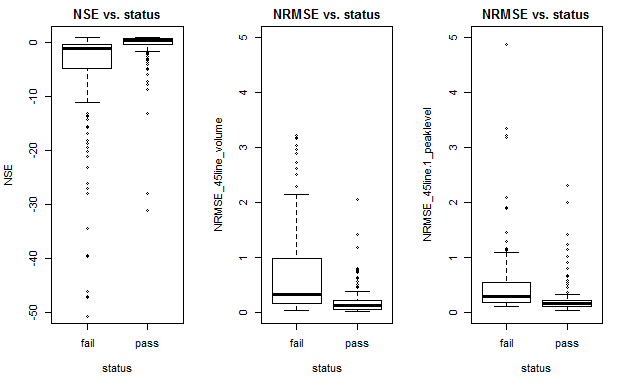

`NRMSE_45line_volume` is used to characterize the deviation of model to an ideal fit. The Rsq vs. NRMSE for volume scatterplot shows an inversed trend. `NRMSE_fit_volume` fits tighter than `NRMSE_45line_volume` because that’s how Rsq was calculated.

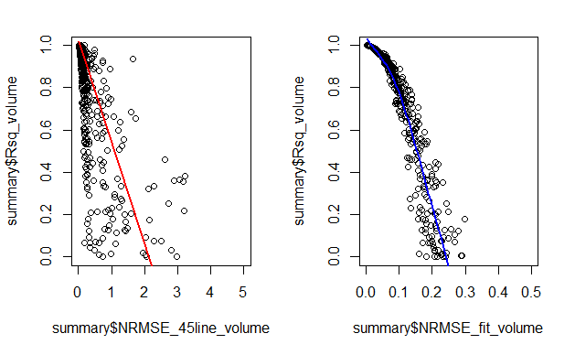

|  | site | valid_status | NSE_good_events | p(NSE>0) | NRMSE_45line_volume | NRMSE_45line.1_peaklevel |
| --- | --- | --- | --- | --- | --- | --- |
| 1 | C_01_SWO_LEVEL | fail | -0.106 | 0.03846154 | 3.04197410 | 0.46220667 |
| 2 | C_01_TRUNK_LEVEL | pass | 0.511 | 0.65384615 | 0.18206960 | 0.16343258 |
| 3 | C_04_SWO_LEVEL | pass | -2.939 | 0.00000000 | 0.32855024 | 0.13897976 |
| 4 | C_04_TRUNK_LEVEL | fail | -0.124 | 0.32000000 | 0.25188262 | 0.29941222 |
| 5 | C_05_DWO_LEVEL | pass | 0.296 | 0.79591837 | 0.20552475 | 2.30189251 |
| 6 | C_05_SWO_LEVEL | fail | -1.878 | 0.00000000 | 0.82148386 | 0.14199118 |
| 7 | C_05_TRUNK_LEVEL | pass | 0.457 | 0.79591837 | 0.17821415 | 0.67018536 |
| 8 | C_06_SWO_LEVEL | pass | -0.555 | 0.09615385 | 0.23715066 | 0.11071646 |
| 9 | C_06_TRUNK_LEVEL | pass | 0.028 | 0.30769231 | 0.10048034 | 0.15590432 |
| 10 | C_07_SWO_LEVEL | pass | 0.129 | 0.16326531 | 0.55814854 | 0.17867651 |

[output cut: 382 more lines]

The summary is shown below:

```
     site           valid_status NSE_good_events        p(NSE>0)
 Length:392         fail:207     Min.   :-376.0130   Min.   :0.00000
 Class :character   pass:185     1st Qu.:  -0.9848   1st Qu.:0.03846
 Mode  :character                Median :  -0.0750   Median :0.15686
                                 Mean   :  -3.1967   Mean   :0.29270
                                 3rd Qu.:   0.4270   3rd Qu.:0.51923
                                 Max.   :   0.9900   Max.   :1.00000
 NRMSE_45line_volume NRMSE_45line.1_peaklevel
 Min.   :  0.0101    Min.   : 0.03536
 1st Qu.:  0.1081    1st Qu.: 0.14054
 Median :  0.1903    Median : 0.20576
 Mean   :  3.3549    Mean   : 0.50493
 3rd Qu.:  0.5603    3rd Qu.: 0.35491
 Max.   :613.8673    Max.   :52.55274
```

The probabilities of pass and fail are relatively balanced:

```
     fail      pass
0.5280612 0.4719388
```

Check if any predictor is highly correlated. As seen, “NRMSE_45line.1_peaklevel” is found, and should be excluded from the model.

```
[1] "NRMSE_45line.1_peaklevel"
```

#### Logistic regression:

Two predictors, `p(NSE>0)` and `NRMSE_45line_volume`, were selected and 3 models were tested for logistic regression by adding one predictor progressively.

Results show that *fit1* has the lowest AIC number, but the difference is not that significant.

```
    fit0     fit1     fit2
461.3959 456.6230 521.4987
```

To visualize the model in *fit1*, a 3D object is generated (predict outcome vs cartesian product of predictors). As seen, `NRMSE_45line_volume` only showed a minimum effects to the model. Therefore, `p(NSE>0)` is used as the sole predictor.

```
                            OR      2.5 %    97.5 %
(Intercept)          0.4186374  0.2969364  0.589023
`p(NSE>0)`          23.2014540 10.2939007 55.565700
NRMSE_45line_volume  0.8321786  0.6369342  0.981983
```

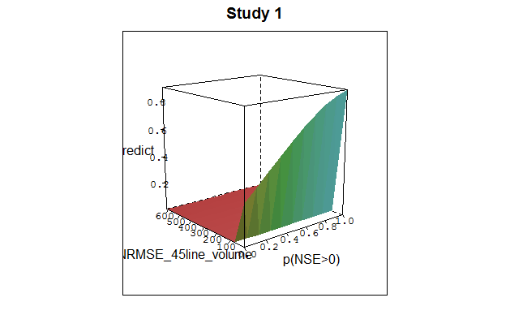

[interactive chart not shown]

### Cut-off Value

To train and evaluate the model, **80%** of the dataset will be used to actually train the model, while the rest will be used to evaluate the accuracy of this model, i.e. out of sample error.

```
[[1]]
             Estimate Std. Error   z value     Pr(>|z|)
(Intercept) -1.027522  0.1727725 -5.947258 2.726718e-09
`p(NSE>0)`   3.269817  0.4678024  6.989741 2.753951e-12

[[2]]
[1] 0.15
```

The pseudo Rsq, calculated from the deviances of null and alternative hypothesis, indicates that only 15% of the variance is explained by the predictor. As of now, there is not much we can do about it unless the dataset is improved.

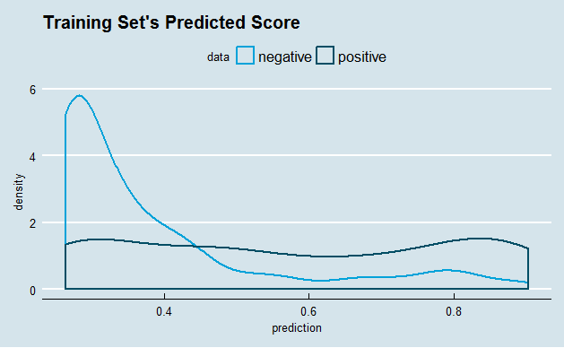

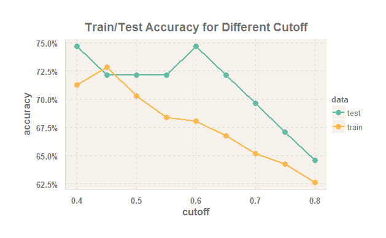

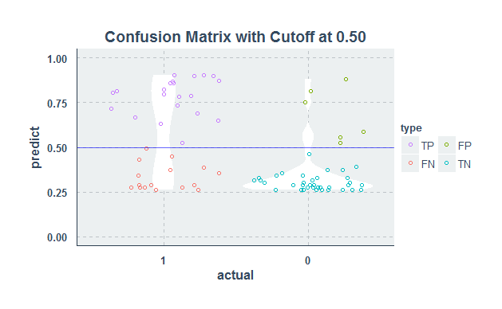

The panelty/cost of FP (failed to detect a bad site) is set to be twice as the FN (failed to detect a good site), because we want to identify more bad sites so we can better adjust the model.

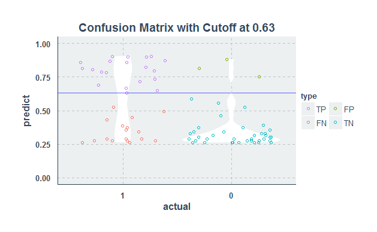

Therefore, the cutoff is set to 0.63.

The model coefficients (expressed as probability) are showns below:

| term | estimate | statistic |
| --- | --- | --- |
| (Intercept) | 0.3578925 | -5.947258 |
| `p(NSE>0)` | 26.3065370 | 6.989741 |

### Model Adjustment Priority

The model adjustment priority is determined by two factors:

- p(NSE>0) (primary)
- Annual Overflow Volume (secondary)

The annaul overflow volumes are acquired from 2016Q2 DMR, located at: `D:\Data\2016_Q2_DMR`

Each site (reg-meas) is ranked based on those factors, and classified into 4 priority list

|  | site | p(NSE>0) | TotVolOvrflwd.cu.ft. | rank | priority |
| --- | --- | --- | --- | --- | --- |
| 290 | S_51_TRUNK_LEVEL | 0.00000000 | 43955337.6 | 1 | high |
| 291 | S_51_SWO_LEVEL | 0.00000000 | 43955337.6 | 2 | high |
| 77 | D_07_SWO_LEVEL | 0.00000000 | 16765264.8 | 3 | high |
| 274 | S_47_TRUNK_LEVEL | 0.00000000 | 4302541.8 | 4 | high |
| 276 | S_47_SWO_LEVEL | 0.00000000 | 4302541.8 | 5 | high |
| 263 | S_39_SWO_LEVEL | 0.00000000 | 1627734.6 | 6 | high |
| 265 | S_39_TRUNK_LEVEL | 0.00000000 | 1627734.6 | 7 | high |
| 156 | D_70_SWO_LEVEL | 0.00000000 | 1381010.4 | 8 | high |
| 158 | D_72_SWO_LEVEL | 0.00000000 | 1362687.3 | 9 | high |
| 25 | C_18_TRUNK_LEVEL | 0.00000000 | 1059499.8 | 10 | high |

[output cut: 382 more lines]